# Face Generation

In this project, you'll use generative adversarial networks to generate new images of faces.

### Get the Data

You'll be using two datasets in this project:

- MNIST
- CelebA

Since the celebA dataset is complex and you're doing GANs in a project for the first time, we want you to test your neural network on MNIST before CelebA. Running the GANs on MNIST will allow you to see how well your model trains sooner.

If you're using [FloydHub](https://www.floydhub.com/), set `data_dir` to "/input" and use the [FloydHub data ID](http://docs.floydhub.com/home/using_datasets/) "R5KrjnANiKVhLWAkpXhNBe".

```python
!mkdir checkpoints data
```

```
mkdir: cannot create directory ‘checkpoints’: File exists
mkdir: cannot create directory ‘data’: File exists
```

```python
data_dir = './data'

# FloydHub - Use with data ID "R5KrjnANiKVhLWAkpXhNBe"
#data_dir = '/input'

"""
DON'T MODIFY ANYTHING IN THIS CELL
"""
import helper

helper.download_extract('mnist', data_dir)
helper.download_extract('celeba', data_dir)
```

```
Found mnist Data
Found celeba Data
```

## Explore the Data

### MNIST

As you're aware, the [MNIST](http://yann.lecun.com/exdb/mnist/) dataset contains images of handwritten digits. You can view the first number of examples by changing `show_n_images`.

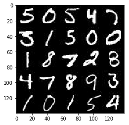

```python
show_n_images = 25

"""
DON'T MODIFY ANYTHING IN THIS CELL
"""
%matplotlib inline
import os
import pickle as pkl
from glob import glob
from matplotlib import pyplot

mnist_images = helper.get_batch(glob(os.path.join(data_dir, 'mnist/*.jpg'))[:show_n_images], 28, 28, 'L')
pyplot.imshow(helper.images_square_grid(mnist_images, 'L'), cmap='gray')
```

### CelebA

The [CelebFaces Attributes Dataset (CelebA)](http://mmlab.ie.cuhk.edu.hk/projects/CelebA.html) dataset contains over 200,000 celebrity images with annotations. Since you're going to be generating faces, you won't need the annotations. You can view the first number of examples by changing `show_n_images`.

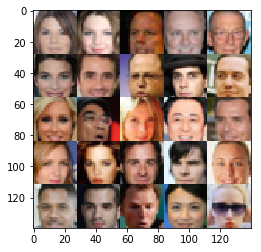

```python
show_n_images = 25

"""
DON'T MODIFY ANYTHING IN THIS CELL
"""
mnist_images = helper.get_batch(glob(os.path.join(data_dir, 'img_align_celeba/*.jpg'))[:show_n_images], 28, 28, 'RGB')
pyplot.imshow(helper.images_square_grid(mnist_images, 'RGB'))
```

## Preprocess the Data

Since the project's main focus is on building the GANs, we'll preprocess the data for you. The values of the MNIST and CelebA dataset will be in the range of -0.5 to 0.5 of 28x28 dimensional images. The CelebA images will be cropped to remove parts of the image that don't include a face, then resized down to 28x28.

The MNIST images are black and white images with a single color channel while the CelebA images have 3 color channels (RGB color channel).

## Build the Neural Network

You'll build the components necessary to build a GANs by implementing the following functions below:

- `model_inputs`
- `discriminator`
- `generator`
- `model_loss`
- `model_opt`
- `train`

### Check the Version of TensorFlow and Access to GPU

This will check to make sure you have the correct version of TensorFlow and access to a GPU

```python
"""
DON'T MODIFY ANYTHING IN THIS CELL
"""
from distutils.version import LooseVersion
import warnings
import tensorflow as tf

# Check TensorFlow Version
assert LooseVersion(tf.__version__) >= LooseVersion('1.0'), 'Please use TensorFlow version 1.0 or newer.  You are using {}'.format(tf.__version__)
print('TensorFlow Version: {}'.format(tf.__version__))

# Check for a GPU
if not tf.test.gpu_device_name():
    warnings.warn('No GPU found. Please use a GPU to train your neural network.')
else:
    print('Default GPU Device: {}'.format(tf.test.gpu_device_name()))
```

```
TensorFlow Version: 1.4.1
Default GPU Device: /device:GPU:0
```

### Input

Implement the `model_inputs` function to create TF Placeholders for the Neural Network. It should create the following placeholders:

- Real input images placeholder with rank 4 using `image_width`, `image_height`, and `image_channels`.
- Z input placeholder with rank 2 using `z_dim`.
- Learning rate placeholder with rank 0.

Return the placeholders in the following the tuple (tensor of real input images, tensor of z data)

```python
import problem_unittests as tests

def model_inputs(image_width, image_height, image_channels, z_dim):
    """
    Create the model inputs
    :param image_width: The input image width
    :param image_height: The input image height
    :param image_channels: The number of image channels
    :param z_dim: The dimension of Z
    :return: Tuple of (tensor of real input images, tensor of z data, learning rate)
    """
    # TODO: Implement Function
    inputs_real = tf.placeholder(tf.float32, [None, image_width, image_height, image_channels], name='inputs_real')
    inputs_z = tf.placeholder(tf.float32, [None, z_dim])
    learning_rate = tf.placeholder(tf.float32)

    return inputs_real, inputs_z, learning_rate


"""
DON'T MODIFY ANYTHING IN THIS CELL THAT IS BELOW THIS LINE
"""
tests.test_model_inputs(model_inputs)
```

```
Tests Passed
```

### Discriminator

Implement `discriminator` to create a discriminator neural network that discriminates on `images`. This function should be able to reuse the variables in the neural network. Use [`tf.variable_scope`](https://www.tensorflow.org/api_docs/python/tf/variable_scope) with a scope name of "discriminator" to allow the variables to be reused. The function should return a tuple of (tensor output of the discriminator, tensor logits of the discriminator).

```python
def discriminator(images, reuse=False, alpha=0.2):
    """
    Create the discriminator network
    :param images: Tensor of input image(s)
    :param reuse: Boolean if the weights should be reused
    :return: Tuple of (tensor output of the discriminator, tensor logits of the discriminator)
    """
    # TODO: Implement Function
    with tf.variable_scope('discriminator', reuse=reuse):
        #width, height, channel = images.shape[1], images.shape[2], images.shape[3]

        # Conv1
        # input: 28 x 28 x 3
        x0 = tf.layers.conv2d(images, filters=64, kernel_size=5, strides=2, padding='same')
        #print (x0.get_shape().as_list())
        x0 = tf.layers.batch_normalization(x0, training=True)
        x0 = tf.maximum(alpha * x0, x0)
        x0 = tf.layers.dropout(x0, 0.5)

        # Conv2
        x1 = tf.layers.conv2d(x0, filters=128, kernel_size=5, strides=2, padding='same')
        #print (x1.get_shape().as_list())
        x1 = tf.layers.batch_normalization(x1, training=True)
        x1 = tf.maximum(alpha * x1, x1)
        x1 = tf.layers.dropout(x1, 0.5)

        # Conv3
        x2 = tf.layers.conv2d(x1, filters=256, kernel_size=5, strides=2, padding='same')
        #print (x2.get_shape().as_list())
        x2 = tf.layers.batch_normalization(x2, training=True)
        x2 = tf.maximum(alpha * x2, x2)
        x2 = tf.layers.dropout(x2, 0.5)

        # Flattening
        conv_shape = x2.get_shape().as_list()
        flat = tf.reshape(x2, [-1, conv_shape[1] * conv_shape[2] * conv_shape[3]])

        # Logits
        logits = tf.layers.dense(flat, 1)

        # Activation
        output = tf.sigmoid(logits)

    return (output, logits)


"""
DON'T MODIFY ANYTHING IN THIS CELL THAT IS BELOW THIS LINE
"""
tests.test_discriminator(discriminator, tf)
```

```
Tests Passed
```

### Generator

Implement `generator` to generate an image using `z`. This function should be able to reuse the variables in the neural network. Use [`tf.variable_scope`](https://www.tensorflow.org/api_docs/python/tf/variable_scope) with a scope name of "generator" to allow the variables to be reused. The function should return the generated 28 x 28 x `out_channel_dim` images.

```python
def generator(z, out_channel_dim, is_train=True, alpha=0.2):
    """
    Create the generator network
    :param z: Input z
    :param out_channel_dim: The number of channels in the output image
    :param is_train: Boolean if generator is being used for training
    :return: The tensor output of the generator
    """
    # TODO: Implement Function
    with tf.variable_scope('generator', reuse=(not is_train)):

        #width, height, channel = z.shape[1], z.shape[2], z.shape[3]

        # Fully connected
        x0 = tf.layers.dense(z, 7*7*512)
        #x0 = tf.layers.dense(z, 2*2*512)
        #print (x0.get_shape().as_list())

        # Reshape as Conv0
        x1 = tf.reshape(x0, (-1, 7, 7, 512))
        #x1 = tf.reshape(x0, (-1, 2, 2, 512))
        # shape: 7 x 7 x 256
        #print (x1.get_shape().as_list())
        x1 = tf.layers.batch_normalization(x1, training=is_train)
        x1 = tf.maximum(alpha * x1, x1)
        #x1 = tf.layers.dropout(x1, 0.5)

        # Conv1
        #x2 = tf.layers.conv2d_transpose(x1, 128, 5, strides=2, padding='same')
        x2 = tf.layers.conv2d_transpose(x1, 256, 5, strides=1, padding='same', activation=None)
        # shape: 8 x 8 x 256
        #print (x2.get_shape().as_list())
        x2 = tf.layers.batch_normalization(x2, training=is_train)
        x2 = tf.maximum(alpha * x2, x2)
        #x2 = tf.layers.dropout(x2, 0.5)

        # Conv2

        x3 = tf.layers.conv2d_transpose(x2, 128, 5, strides=2, padding='same', activation=None)
        # shape: 16 x 16 x 128
        #print (x3.get_shape().as_list())
        x3 = tf.layers.batch_normalization(x3, training=is_train)
        x3 = tf.maximum(alpha * x3, x3)
        #x3 = tf.layers.dropout(x3, 0.5)
        """
        # Conv3
        x4 = tf.layers.conv2d_transpose(x3, 64, 3, strides=2, padding='same')
        # shape: 16 x 16 x 128
        #print (x3.get_shape().as_list())
        x4 = tf.layers.batch_normalization(x4, training=is_train)
        x4 = tf.maximum(alpha * x4, x4)
        #x3 = tf.layers.dropout(x3, 0.5)
        """
        # Output layer
        logits = tf.layers.conv2d_transpose(x3, out_channel_dim, 5, strides=2, padding='same', activation=None)
        # shape: 32 x 32 x out_channel_dim
        #print (logits.get_shape().as_list())

        out = tf.tanh(logits)
        #print (out.get_shape().as_list())
    return out


"""
DON'T MODIFY ANYTHING IN THIS CELL THAT IS BELOW THIS LINE
"""
tests.test_generator(generator, tf)
```

```
Tests Passed
```

### Loss

Implement `model_loss` to build the GANs for training and calculate the loss. The function should return a tuple of (discriminator loss, generator loss). Use the following functions you implemented:

- `discriminator(images, reuse=False)`
- `generator(z, out_channel_dim, is_train=True)`

```python
def model_loss(input_real, input_z, out_channel_dim, smooth=0.1, alpha=0.2):
    """
    Get the loss for the discriminator and generator
    :param input_real: Images from the real dataset
    :param input_z: Z input
    :param out_channel_dim: The number of channels in the output image
    :param smooth: float, regularize the discriminator
    :return: A tuple of (discriminator loss, generator loss)
    """
    # TODO: Implement Function
    g_model = generator(input_z, out_channel_dim, alpha=alpha)

    d_model_real = discriminator(input_real, alpha=alpha)
    # Forward prop: Set reuse=True
    d_model_fake = discriminator(g_model, reuse=True, alpha=alpha)

    d_loss_real = tf.reduce_mean(
        tf.nn.sigmoid_cross_entropy_with_logits(logits=d_model_real,
                                                labels=tf.ones_like(d_model_real) * (1 - smooth))
    )
    d_loss_fake = tf.reduce_mean(
        tf.nn.sigmoid_cross_entropy_with_logits(logits=d_model_fake, labels=tf.zeros_like(d_model_fake))
    )
    d_loss = d_loss_real + d_loss_fake

    g_loss = tf.reduce_mean(
        tf.nn.sigmoid_cross_entropy_with_logits(logits=d_model_fake, labels=tf.ones_like(d_model_fake))
    )

    return d_loss, g_loss


"""
DON'T MODIFY ANYTHING IN THIS CELL THAT IS BELOW THIS LINE
"""
tests.test_model_loss(model_loss)
```

```
Tests Passed
```

### Optimization

Implement `model_opt` to create the optimization operations for the GANs. Use [`tf.trainable_variables`](https://www.tensorflow.org/api_docs/python/tf/trainable_variables) to get all the trainable variables. Filter the variables with names that are in the discriminator and generator scope names. The function should return a tuple of (discriminator training operation, generator training operation).

```python
def model_opt(d_loss, g_loss, learning_rate, beta1):
    """
    Get optimization operations
    :param d_loss: Discriminator loss Tensor
    :param g_loss: Generator loss Tensor
    :param learning_rate: Learning Rate Placeholder
    :param beta1: The exponential decay rate for the 1st moment in the optimizer
    :return: A tuple of (discriminator training operation, generator training operation)
    """
    # TODO: Implement Function
    trainable_vars = tf.trainable_variables()
    d_vars = [var for var in trainable_vars if var.name.startswith('discriminator')]
    g_vars = [var for var in trainable_vars if var.name.startswith('generator')]

    # Optimization
    with tf.control_dependencies(tf.get_collection(tf.GraphKeys.UPDATE_OPS)):
        d_opt = tf.train.AdamOptimizer(
            learning_rate=learning_rate,
            beta1=beta1
        ).minimize(d_loss, var_list=d_vars)

        g_opt = tf.train.AdamOptimizer(
            learning_rate=learning_rate,
            beta1=beta1
        ).minimize(g_loss, var_list=g_vars)

    return d_opt, g_opt


"""
DON'T MODIFY ANYTHING IN THIS CELL THAT IS BELOW THIS LINE
"""
tests.test_model_opt(model_opt, tf)
```

```
Tests Passed
```

## Neural Network Training

### Show Output

Use this function to show the current output of the generator during training. It will help you determine how well the GANs is training.

```python
"""
DON'T MODIFY ANYTHING IN THIS CELL
"""
import numpy as np

def show_generator_output(sess, n_images, input_z, out_channel_dim, image_mode):
    """
    Show example output for the generator
    :param sess: TensorFlow session
    :param n_images: Number of Images to display
    :param input_z: Input Z Tensor
    :param out_channel_dim: The number of channels in the output image
    :param image_mode: The mode to use for images ("RGB" or "L")
    """
    cmap = None if image_mode == 'RGB' else 'gray'
    z_dim = input_z.get_shape().as_list()[-1]
    example_z = np.random.uniform(-1, 1, size=[n_images, z_dim])

    samples = sess.run(
        generator(input_z, out_channel_dim, False),
        feed_dict={
            input_z: example_z,
        })

    images_grid = helper.images_square_grid(samples, image_mode)
    pyplot.imshow(images_grid, cmap=cmap)
    pyplot.show()

    return samples
```

### Train

Implement `train` to build and train the GANs. Use the following functions you implemented:

- `model_inputs(image_width, image_height, image_channels, z_dim)`
- `model_loss(input_real, input_z, out_channel_dim)`
- `model_opt(d_loss, g_loss, learning_rate, beta1)`

Use the `show_generator_output` to show `generator` output while you train. Running `show_generator_output` for every batch will drastically increase training time and increase the size of the notebook. It's recommended to print the `generator` output every 100 batches.

```python
def train(epoch_count, batch_size, z_dim, learning_rate, beta1, get_batches, data_shape, data_image_mode,
         print_loss_every=10, show_sample_every=100, data_name='CelebA'):
    """
    Train the GAN
    :param epoch_count: Number of epochs
    :param batch_size: Batch Size
    :param z_dim: Z dimension
    :param learning_rate: Learning Rate
    :param beta1: The exponential decay rate for the 1st moment in the optimizer
    :param get_batches: Function to get batches
    :param data_shape: Shape of the data
    :param data_image_mode: The image mode to use for images ("RGB" or "L")
    """
    # TODO: Build Model

    # Plotting for Later Analysis
    samples, losses = [], []
    # Counting Steps to print messages
    steps = 0
    # Z distribution
    # showing 72 images at a time
    #print ("Z Dim:", z_dim)
    #print ("Z type:", z_dim.type)
    #sample_z = np.random.uniform(-1, 1, size=(72, z_dim))

    # Initialize Inputs
    image_width, image_height, image_channels = data_shape[1], data_shape[2], data_shape[3]
    inputs_real, inputs_z, lr = model_inputs(image_width, image_height, image_channels, z_dim)

    # Set image_mode
    image_mode = "RGB" if image_channels == 3 else "L"

    # Initialize Losses
    d_loss, g_loss = model_loss(inputs_real, inputs_z, image_channels)

    # Initialize Opts
    d_opt, g_opt = model_opt(d_loss, g_loss, lr, beta1)

    with tf.Session() as sess:
        sess.run(tf.global_variables_initializer())
        for epoch_i in range(epoch_count):
            for batch_images in get_batches(batch_size):
                # TODO: Train Model
                # Count Steps
                steps += 1

                # Sample random noise from G
                batch_z = np.random.uniform(-1, 1, size=(batch_size, z_dim))

                # Scale the real input images
                # from [-0.5, 0.5] to [-1, 1]
                batch_images *= 2

                # Optimization
                _ = sess.run(d_opt, feed_dict={
                    inputs_real: batch_images,
                    inputs_z: batch_z,
                    lr: learning_rate,
                })

                # run the generator twice
                _ = sess.run(g_opt, feed_dict={
                    inputs_real: batch_images, # necessary to avoid error, not necessary for the algo
                    inputs_z: batch_z,
                    lr: learning_rate,
                })
                """
                _ = sess.run(g_opt, feed_dict={
                    inputs_real: batch_images, # necessary to avoid error, not necessary for the algo
                    inputs_z: batch_z,
                    lr: learning_rate,
                })
                """



                # Pirnt Loss
                if steps % print_loss_every == 0:
                    """
                    train_loss_d = sess.run(d_loss, feed_dict={
                        inputs_real: batch_images,
                        inputs_z: batch_z,
                        #learning_rate: learning_rate,
                    })
                    train_loss_g = sess.run(g_loss, feed_dict={
                        inputs_z: batch_z,
                    })
                    """
                    train_loss_d = d_loss.eval({
                        inputs_real: batch_images,
                        inputs_z: batch_z,
                    })

                    train_loss_g = g_loss.eval({
                        inputs_z: batch_z,
                    })

                    print ('Epoch {:>3}/{:<3}'.format(epoch_i + 1, epoch_count),
                           'Discriminator Loss: {:7.5f}'.format(train_loss_d),
                           'Generator Loss: {:7.5f}'.format(train_loss_g))

                    #if train_loss_d > train_loss_g:
                    #    print ("!!!Generator beats discriminator!")

                    #if train_loss_g - 0.5 < 0 and data_name == 'CelebA':
                    #    print ("Fake it until you make it!!!")
                    #    show_generator_output(sess, 25, inputs_z, image_channels, image_mode)

                    # save for plotting and analysis
                    losses.append((train_loss_d, train_loss_g))

                # Show samples
                if steps % show_sample_every == 0:
                    current_samples = show_generator_output(sess, 25, inputs_z, image_channels, image_mode)
                    samples.append(current_samples)

        saver = tf.train.Saver()
        save_file = 'dataset:{}_generator_dloss:{:.5f}_gloss:{:.5f}_epochs:{}_lr:{}_batchsize:{}_zdim:{}_beta1:{}'.format(
            data_name, train_loss_d, train_loss_g, epoch_count, learning_rate, batch_size, z_dim, beta1)
        saver.save(sess, os.path.join('./checkpoints', save_file))

    with open('face_generation_samples.pkl', 'wb') as f:
        pkl.dump(samples, f)

    return losses, samples
```

### Plotting Losses

```python
import matplotlib.pyplot as plt

def plot_loss(losses):
    fig, ax = plt.subplots()
    losses = np.array(losses)
    plt.plot(losses.T[0], label='Discriminator', alpha=0.5)
    plt.plot(losses.T[1], label='Generator', alpha=0.5)
    plt.title("Training Losses")
    plt.legend()
```

### View Samples

```python
def view_samples(epoch, samples, nrows, ncols, figsize=(6, 6)):
    fig, axes = plt.subplots(figsize=figsize, nrows=nrows, ncols=ncols,
                            sharey=True, sharex=True)
    for ax, img in zip(axes.flatten(), samples[epoch]):
        ax.axis('off')
        ax.xaxis.set_visible(False)
        ax.yaxis.set_visible(False)
        img = ((img - img.min()) * 255 / (img.max() - img.min())).astype(np.uint8)
        ax.set_adjustable('box-forced')
        im = ax.imshow(img, aspect='equal')

    plt.subplots_adjust(wspace=0, hspace=0)
    return fig, axes
```

### MNIST

Test your GANs architecture on MNIST. After 2 epochs, the GANs should be able to generate images that look like handwritten digits. Make sure the loss of the generator is lower than the loss of the discriminator or close to 0.

```
Epoch   1/2   Discriminator Loss: 1.43692 Generator Loss: 7.29473
Epoch   1/2   Discriminator Loss: 2.19351 Generator Loss: 2.27134
Epoch   1/2   Discriminator Loss: 1.78219 Generator Loss: 1.36482
Epoch   1/2   Discriminator Loss: 1.66981 Generator Loss: 1.02427
Epoch   1/2   Discriminator Loss: 1.60949 Generator Loss: 1.14621
Epoch   1/2   Discriminator Loss: 1.53631 Generator Loss: 0.83656
Epoch   1/2   Discriminator Loss: 1.52566 Generator Loss: 1.11487
Epoch   1/2   Discriminator Loss: 1.58202 Generator Loss: 1.05781
Epoch   1/2   Discriminator Loss: 1.43393 Generator Loss: 0.66845
Epoch   1/2   Discriminator Loss: 1.52277 Generator Loss: 0.84260
```

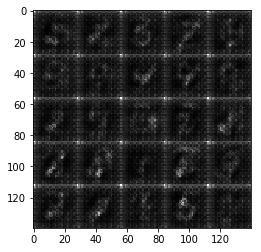

```
Epoch   1/2   Discriminator Loss: 1.48556 Generator Loss: 1.09143
Epoch   1/2   Discriminator Loss: 1.42261 Generator Loss: 0.87934
Epoch   1/2   Discriminator Loss: 1.35666 Generator Loss: 0.81716
Epoch   1/2   Discriminator Loss: 1.34371 Generator Loss: 0.95609
Epoch   1/2   Discriminator Loss: 1.36226 Generator Loss: 1.12899
Epoch   1/2   Discriminator Loss: 1.50729 Generator Loss: 1.35211
Epoch   1/2   Discriminator Loss: 1.48133 Generator Loss: 1.10066
Epoch   1/2   Discriminator Loss: 1.49687 Generator Loss: 1.18852
Epoch   1/2   Discriminator Loss: 1.38819 Generator Loss: 1.11398
Epoch   1/2   Discriminator Loss: 1.43163 Generator Loss: 0.93832
```

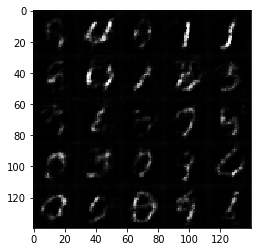

```
Epoch   1/2   Discriminator Loss: 1.37864 Generator Loss: 0.91575
Epoch   1/2   Discriminator Loss: 1.38394 Generator Loss: 1.14168
Epoch   1/2   Discriminator Loss: 1.36059 Generator Loss: 0.70711
Epoch   1/2   Discriminator Loss: 1.58581 Generator Loss: 0.40134
Epoch   1/2   Discriminator Loss: 1.45205 Generator Loss: 0.47741
Epoch   1/2   Discriminator Loss: 1.53538 Generator Loss: 0.42745
Epoch   1/2   Discriminator Loss: 1.50807 Generator Loss: 0.44792
Epoch   1/2   Discriminator Loss: 1.58210 Generator Loss: 0.39756
Epoch   1/2   Discriminator Loss: 1.53416 Generator Loss: 0.43421
Epoch   1/2   Discriminator Loss: 1.52652 Generator Loss: 0.44273
```

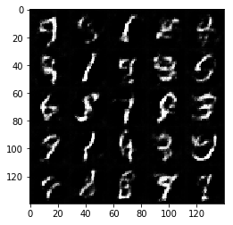

```
Epoch   1/2   Discriminator Loss: 1.54972 Generator Loss: 0.41110
Epoch   1/2   Discriminator Loss: 1.49704 Generator Loss: 0.46396
Epoch   1/2   Discriminator Loss: 1.37596 Generator Loss: 0.56690
Epoch   1/2   Discriminator Loss: 1.38333 Generator Loss: 1.03565
Epoch   1/2   Discriminator Loss: 1.33754 Generator Loss: 1.00548
Epoch   1/2   Discriminator Loss: 1.33229 Generator Loss: 0.98779
Epoch   1/2   Discriminator Loss: 1.42631 Generator Loss: 1.17954
Epoch   1/2   Discriminator Loss: 1.39176 Generator Loss: 1.10648
Epoch   1/2   Discriminator Loss: 1.40604 Generator Loss: 1.12774
Epoch   1/2   Discriminator Loss: 1.31401 Generator Loss: 0.86243
```

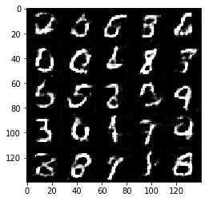

```
Epoch   1/2   Discriminator Loss: 1.42094 Generator Loss: 1.06907
Epoch   1/2   Discriminator Loss: 1.39216 Generator Loss: 0.74341
Epoch   1/2   Discriminator Loss: 1.28614 Generator Loss: 0.70960
Epoch   1/2   Discriminator Loss: 1.78190 Generator Loss: 0.37278
Epoch   1/2   Discriminator Loss: 1.46768 Generator Loss: 0.46674
Epoch   1/2   Discriminator Loss: 1.41499 Generator Loss: 0.48822
Epoch   1/2   Discriminator Loss: 1.47940 Generator Loss: 0.46412
Epoch   1/2   Discriminator Loss: 1.49846 Generator Loss: 0.42976
Epoch   1/2   Discriminator Loss: 1.47127 Generator Loss: 0.45818
Epoch   1/2   Discriminator Loss: 1.49033 Generator Loss: 0.44128
```

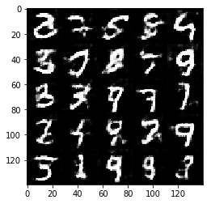

```
Epoch   1/2   Discriminator Loss: 1.51278 Generator Loss: 0.42892
Epoch   1/2   Discriminator Loss: 1.39832 Generator Loss: 0.51161
Epoch   1/2   Discriminator Loss: 1.42539 Generator Loss: 0.51373
Epoch   1/2   Discriminator Loss: 1.44047 Generator Loss: 0.46880
Epoch   1/2   Discriminator Loss: 1.47766 Generator Loss: 0.44666
Epoch   1/2   Discriminator Loss: 1.54097 Generator Loss: 0.40915
Epoch   1/2   Discriminator Loss: 1.44612 Generator Loss: 0.47417
Epoch   1/2   Discriminator Loss: 1.41188 Generator Loss: 0.51325
Epoch   1/2   Discriminator Loss: 1.59681 Generator Loss: 0.37306
Epoch   1/2   Discriminator Loss: 1.35488 Generator Loss: 0.55078
```

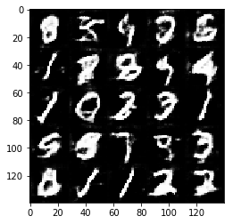

```
Epoch   1/2   Discriminator Loss: 1.49136 Generator Loss: 0.45130
Epoch   1/2   Discriminator Loss: 1.32188 Generator Loss: 0.66245
Epoch   1/2   Discriminator Loss: 1.33862 Generator Loss: 0.56985
Epoch   1/2   Discriminator Loss: 1.29453 Generator Loss: 0.64881
Epoch   1/2   Discriminator Loss: 1.30049 Generator Loss: 1.01563
Epoch   1/2   Discriminator Loss: 1.52366 Generator Loss: 0.44164
Epoch   1/2   Discriminator Loss: 1.82983 Generator Loss: 0.30137
Epoch   1/2   Discriminator Loss: 1.23085 Generator Loss: 0.68447
Epoch   1/2   Discriminator Loss: 1.49579 Generator Loss: 1.47521
Epoch   1/2   Discriminator Loss: 1.18970 Generator Loss: 0.93040
```

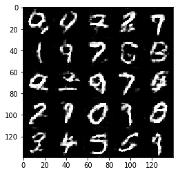

```
Epoch   1/2   Discriminator Loss: 1.78819 Generator Loss: 1.51615
Epoch   1/2   Discriminator Loss: 1.37287 Generator Loss: 0.50903
Epoch   1/2   Discriminator Loss: 1.26128 Generator Loss: 0.60455
Epoch   1/2   Discriminator Loss: 1.45151 Generator Loss: 0.48437
Epoch   1/2   Discriminator Loss: 1.60586 Generator Loss: 0.37238
Epoch   1/2   Discriminator Loss: 1.24924 Generator Loss: 0.99715
Epoch   1/2   Discriminator Loss: 1.35368 Generator Loss: 0.51155
Epoch   1/2   Discriminator Loss: 1.42747 Generator Loss: 0.47922
Epoch   1/2   Discriminator Loss: 1.18312 Generator Loss: 0.75844
Epoch   1/2   Discriminator Loss: 1.54066 Generator Loss: 1.52890
```

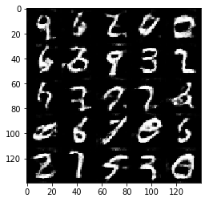

```
Epoch   1/2   Discriminator Loss: 1.41431 Generator Loss: 0.49721
Epoch   1/2   Discriminator Loss: 1.46456 Generator Loss: 0.46400
Epoch   1/2   Discriminator Loss: 1.24114 Generator Loss: 0.64739
Epoch   1/2   Discriminator Loss: 1.12271 Generator Loss: 0.73544
Epoch   1/2   Discriminator Loss: 1.24568 Generator Loss: 0.61768
Epoch   1/2   Discriminator Loss: 1.64349 Generator Loss: 0.36257
Epoch   1/2   Discriminator Loss: 1.30360 Generator Loss: 0.57351
Epoch   1/2   Discriminator Loss: 1.28295 Generator Loss: 0.76312
Epoch   1/2   Discriminator Loss: 1.34700 Generator Loss: 1.18051
Epoch   1/2   Discriminator Loss: 1.07283 Generator Loss: 0.93034
```

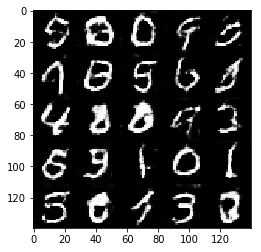

```
Epoch   1/2   Discriminator Loss: 1.09403 Generator Loss: 0.94015
Epoch   1/2   Discriminator Loss: 1.11356 Generator Loss: 0.99355
Epoch   1/2   Discriminator Loss: 1.21106 Generator Loss: 1.40317
Epoch   2/2   Discriminator Loss: 2.22434 Generator Loss: 2.34824
Epoch   2/2   Discriminator Loss: 1.11681 Generator Loss: 0.89915
Epoch   2/2   Discriminator Loss: 1.19928 Generator Loss: 1.42708
Epoch   2/2   Discriminator Loss: 1.10196 Generator Loss: 0.82975
Epoch   2/2   Discriminator Loss: 1.55705 Generator Loss: 1.86475
Epoch   2/2   Discriminator Loss: 1.03330 Generator Loss: 0.96588
Epoch   2/2   Discriminator Loss: 1.06283 Generator Loss: 1.12767
```

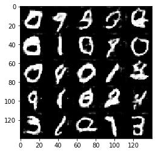

```
Epoch   2/2   Discriminator Loss: 1.41675 Generator Loss: 1.50191
Epoch   2/2   Discriminator Loss: 1.22690 Generator Loss: 1.20174
Epoch   2/2   Discriminator Loss: 1.45631 Generator Loss: 1.56398
Epoch   2/2   Discriminator Loss: 1.20550 Generator Loss: 0.68258
Epoch   2/2   Discriminator Loss: 1.03712 Generator Loss: 0.93928
Epoch   2/2   Discriminator Loss: 1.64740 Generator Loss: 0.36425
Epoch   2/2   Discriminator Loss: 1.28090 Generator Loss: 0.57942
Epoch   2/2   Discriminator Loss: 1.04666 Generator Loss: 1.23568
Epoch   2/2   Discriminator Loss: 1.00063 Generator Loss: 1.29810
Epoch   2/2   Discriminator Loss: 1.31434 Generator Loss: 1.39522
```

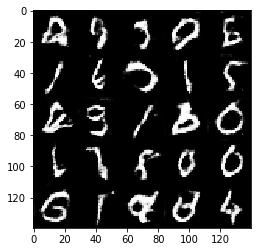

```
Epoch   2/2   Discriminator Loss: 1.07276 Generator Loss: 0.88478
Epoch   2/2   Discriminator Loss: 1.43412 Generator Loss: 1.74689
Epoch   2/2   Discriminator Loss: 1.02575 Generator Loss: 0.93642
Epoch   2/2   Discriminator Loss: 1.00794 Generator Loss: 1.75006
Epoch   2/2   Discriminator Loss: 1.35197 Generator Loss: 0.53532
Epoch   2/2   Discriminator Loss: 1.79794 Generator Loss: 0.33683
Epoch   2/2   Discriminator Loss: 0.95617 Generator Loss: 1.06124
Epoch   2/2   Discriminator Loss: 0.92454 Generator Loss: 1.14483
Epoch   2/2   Discriminator Loss: 1.56638 Generator Loss: 0.45026
Epoch   2/2   Discriminator Loss: 0.95094 Generator Loss: 1.29696
```

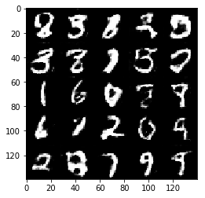

```
Epoch   2/2   Discriminator Loss: 0.93783 Generator Loss: 1.42972
Epoch   2/2   Discriminator Loss: 1.14659 Generator Loss: 1.08197
Epoch   2/2   Discriminator Loss: 1.00245 Generator Loss: 0.97478
Epoch   2/2   Discriminator Loss: 1.76965 Generator Loss: 0.32044
Epoch   2/2   Discriminator Loss: 1.47326 Generator Loss: 0.46075
Epoch   2/2   Discriminator Loss: 1.47148 Generator Loss: 0.48352
Epoch   2/2   Discriminator Loss: 1.47390 Generator Loss: 0.44625
Epoch   2/2   Discriminator Loss: 0.93354 Generator Loss: 1.23154
Epoch   2/2   Discriminator Loss: 1.10016 Generator Loss: 0.77591
Epoch   2/2   Discriminator Loss: 1.24339 Generator Loss: 0.65672
```

[6 more figures not shown]

```
Epoch   2/2   Discriminator Loss: 1.01951 Generator Loss: 0.90572
Epoch   2/2   Discriminator Loss: 1.13386 Generator Loss: 2.30572
Epoch   2/2   Discriminator Loss: 1.02798 Generator Loss: 1.35535
Epoch   2/2   Discriminator Loss: 1.55745 Generator Loss: 1.67272
Epoch   2/2   Discriminator Loss: 0.93407 Generator Loss: 1.18783
Epoch   2/2   Discriminator Loss: 0.88646 Generator Loss: 1.25518
Epoch   2/2   Discriminator Loss: 0.84216 Generator Loss: 1.59166
```

```python
batch_size = 64
z_dim = 100
learning_rate = 0.0005
beta1 = 0.2

"""
DON'T MODIFY ANYTHING IN THIS CELL THAT IS BELOW THIS LINE
"""
epochs = 2

mnist_dataset = helper.Dataset('mnist', glob(os.path.join(data_dir, 'mnist/*.jpg')))
with tf.Graph().as_default():
    mnist_losses, mnist_samples = train(epochs, batch_size, z_dim, learning_rate,
                                        beta1, mnist_dataset.get_batches,
                                        mnist_dataset.shape, mnist_dataset.image_mode, data_name='MNIST')
```

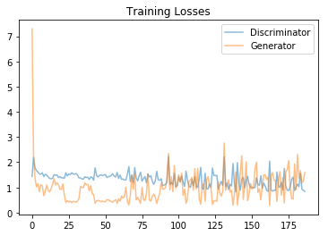

```python
plot_loss(mnist_losses)
```

### CelebA

Run your GANs on CelebA. It will take around 20 minutes on the average GPU to run one epoch. You can run the whole epoch or stop when it starts to generate realistic faces.

```
Epoch   1/1   Discriminator Loss: 1.62301 Generator Loss: 3.77540
Epoch   1/1   Discriminator Loss: 2.25730 Generator Loss: 2.51442
Epoch   1/1   Discriminator Loss: 1.85991 Generator Loss: 1.71465
Epoch   1/1   Discriminator Loss: 1.70653 Generator Loss: 1.12245
Epoch   1/1   Discriminator Loss: 1.74083 Generator Loss: 0.87229
Epoch   1/1   Discriminator Loss: 1.60286 Generator Loss: 0.74456
Epoch   1/1   Discriminator Loss: 1.34592 Generator Loss: 1.07751
Epoch   1/1   Discriminator Loss: 1.61644 Generator Loss: 1.34743
Epoch   1/1   Discriminator Loss: 1.51876 Generator Loss: 1.01420
Epoch   1/1   Discriminator Loss: 1.60553 Generator Loss: 1.14443
```

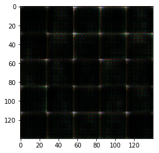

```
Epoch   1/1   Discriminator Loss: 1.43448 Generator Loss: 1.00892
Epoch   1/1   Discriminator Loss: 1.41061 Generator Loss: 1.18648
Epoch   1/1   Discriminator Loss: 1.53025 Generator Loss: 1.09986
Epoch   1/1   Discriminator Loss: 1.47313 Generator Loss: 0.78991
Epoch   1/1   Discriminator Loss: 1.51459 Generator Loss: 0.62740
Epoch   1/1   Discriminator Loss: 1.41788 Generator Loss: 0.50199
Epoch   1/1   Discriminator Loss: 1.35776 Generator Loss: 0.57574
Epoch   1/1   Discriminator Loss: 1.28328 Generator Loss: 0.71705
Epoch   1/1   Discriminator Loss: 1.38032 Generator Loss: 0.54128
Epoch   1/1   Discriminator Loss: 1.82656 Generator Loss: 0.29692
```

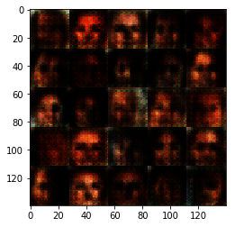

```
Epoch   1/1   Discriminator Loss: 1.52708 Generator Loss: 0.44869
Epoch   1/1   Discriminator Loss: 1.06325 Generator Loss: 0.88343
Epoch   1/1   Discriminator Loss: 1.35031 Generator Loss: 1.78328
Epoch   1/1   Discriminator Loss: 1.27019 Generator Loss: 1.56222
Epoch   1/1   Discriminator Loss: 0.87451 Generator Loss: 1.35833
Epoch   1/1   Discriminator Loss: 1.00922 Generator Loss: 1.03774
Epoch   1/1   Discriminator Loss: 1.67200 Generator Loss: 1.18360
Epoch   1/1   Discriminator Loss: 1.61617 Generator Loss: 2.57171
Epoch   1/1   Discriminator Loss: 1.27090 Generator Loss: 0.56992
Epoch   1/1   Discriminator Loss: 1.72141 Generator Loss: 0.32985
```

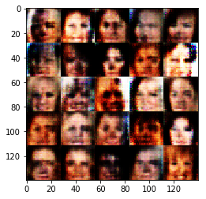

```
Epoch   1/1   Discriminator Loss: 1.10706 Generator Loss: 0.73285
Epoch   1/1   Discriminator Loss: 1.01250 Generator Loss: 0.89142
Epoch   1/1   Discriminator Loss: 1.40682 Generator Loss: 2.05984
Epoch   1/1   Discriminator Loss: 0.95823 Generator Loss: 2.27418
Epoch   1/1   Discriminator Loss: 0.84995 Generator Loss: 1.31534
Epoch   1/1   Discriminator Loss: 0.95855 Generator Loss: 1.11802
Epoch   1/1   Discriminator Loss: 1.10161 Generator Loss: 1.65823
Epoch   1/1   Discriminator Loss: 1.20198 Generator Loss: 1.62331
Epoch   1/1   Discriminator Loss: 1.63994 Generator Loss: 2.11816
Epoch   1/1   Discriminator Loss: 0.81868 Generator Loss: 1.54969
```

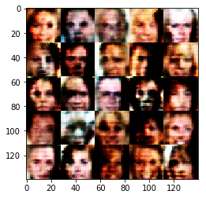

```
Epoch   1/1   Discriminator Loss: 1.32626 Generator Loss: 1.80769
Epoch   1/1   Discriminator Loss: 1.37790 Generator Loss: 1.03775
Epoch   1/1   Discriminator Loss: 1.13825 Generator Loss: 1.77373
Epoch   1/1   Discriminator Loss: 1.12019 Generator Loss: 1.89664
Epoch   1/1   Discriminator Loss: 1.51729 Generator Loss: 1.52495
Epoch   1/1   Discriminator Loss: 1.01765 Generator Loss: 1.95973
Epoch   1/1   Discriminator Loss: 1.44773 Generator Loss: 2.15775
Epoch   1/1   Discriminator Loss: 1.11079 Generator Loss: 1.13315
Epoch   1/1   Discriminator Loss: 1.51803 Generator Loss: 0.42209
Epoch   1/1   Discriminator Loss: 1.11709 Generator Loss: 1.07770
```

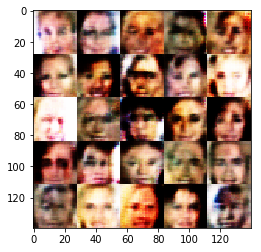

```
Epoch   1/1   Discriminator Loss: 1.11445 Generator Loss: 1.83100
Epoch   1/1   Discriminator Loss: 1.49878 Generator Loss: 0.43375
Epoch   1/1   Discriminator Loss: 1.39642 Generator Loss: 1.61663
Epoch   1/1   Discriminator Loss: 0.89909 Generator Loss: 1.79675
Epoch   1/1   Discriminator Loss: 1.03617 Generator Loss: 1.30902
Epoch   1/1   Discriminator Loss: 1.39981 Generator Loss: 0.49648
Epoch   1/1   Discriminator Loss: 1.18424 Generator Loss: 0.70602
Epoch   1/1   Discriminator Loss: 1.14680 Generator Loss: 1.06271
Epoch   1/1   Discriminator Loss: 1.27332 Generator Loss: 0.62138
Epoch   1/1   Discriminator Loss: 1.32312 Generator Loss: 0.57237
```

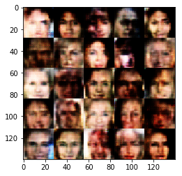

```
Epoch   1/1   Discriminator Loss: 1.33805 Generator Loss: 0.52670
Epoch   1/1   Discriminator Loss: 1.16717 Generator Loss: 0.67200
Epoch   1/1   Discriminator Loss: 1.01582 Generator Loss: 1.11007
Epoch   1/1   Discriminator Loss: 1.63257 Generator Loss: 1.84914
Epoch   1/1   Discriminator Loss: 0.80584 Generator Loss: 1.78779
Epoch   1/1   Discriminator Loss: 1.79573 Generator Loss: 0.33087
Epoch   1/1   Discriminator Loss: 1.28583 Generator Loss: 0.58418
Epoch   1/1   Discriminator Loss: 1.11439 Generator Loss: 1.92168
Epoch   1/1   Discriminator Loss: 1.38161 Generator Loss: 1.56293
Epoch   1/1   Discriminator Loss: 1.58661 Generator Loss: 1.48836
```

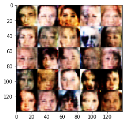

```
Epoch   1/1   Discriminator Loss: 1.08426 Generator Loss: 1.49726
Epoch   1/1   Discriminator Loss: 0.86350 Generator Loss: 1.32500
Epoch   1/1   Discriminator Loss: 1.37590 Generator Loss: 0.86323
Epoch   1/1   Discriminator Loss: 1.08458 Generator Loss: 1.24322
Epoch   1/1   Discriminator Loss: 1.36882 Generator Loss: 1.38824
Epoch   1/1   Discriminator Loss: 1.46243 Generator Loss: 2.65510
Epoch   1/1   Discriminator Loss: 0.84755 Generator Loss: 1.77790
Epoch   1/1   Discriminator Loss: 1.30832 Generator Loss: 1.00083
Epoch   1/1   Discriminator Loss: 1.26434 Generator Loss: 1.05511
Epoch   1/1   Discriminator Loss: 1.61367 Generator Loss: 1.52654
```

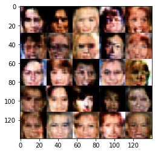

```
Epoch   1/1   Discriminator Loss: 1.09677 Generator Loss: 0.85528
Epoch   1/1   Discriminator Loss: 0.92243 Generator Loss: 1.37002
Epoch   1/1   Discriminator Loss: 1.13616 Generator Loss: 1.29377
Epoch   1/1   Discriminator Loss: 1.18735 Generator Loss: 1.33682
Epoch   1/1   Discriminator Loss: 1.15617 Generator Loss: 1.44445
Epoch   1/1   Discriminator Loss: 1.38705 Generator Loss: 1.23846
Epoch   1/1   Discriminator Loss: 1.07489 Generator Loss: 0.80148
Epoch   1/1   Discriminator Loss: 1.14960 Generator Loss: 1.12729
Epoch   1/1   Discriminator Loss: 1.22307 Generator Loss: 0.66489
Epoch   1/1   Discriminator Loss: 1.30361 Generator Loss: 0.58972
```

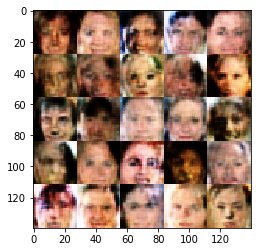

```
Epoch   1/1   Discriminator Loss: 1.19989 Generator Loss: 0.66454
Epoch   1/1   Discriminator Loss: 1.15724 Generator Loss: 0.71045
Epoch   1/1   Discriminator Loss: 1.45149 Generator Loss: 1.47129
Epoch   1/1   Discriminator Loss: 1.22064 Generator Loss: 1.65216
Epoch   1/1   Discriminator Loss: 0.98282 Generator Loss: 1.13912
Epoch   1/1   Discriminator Loss: 1.08274 Generator Loss: 1.89084
Epoch   1/1   Discriminator Loss: 1.43041 Generator Loss: 1.59484
Epoch   1/1   Discriminator Loss: 1.21523 Generator Loss: 1.01534
Epoch   1/1   Discriminator Loss: 1.24832 Generator Loss: 0.76424
Epoch   1/1   Discriminator Loss: 1.00567 Generator Loss: 0.90647
```

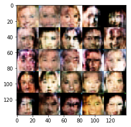

```
Epoch   1/1   Discriminator Loss: 1.67747 Generator Loss: 1.88483
Epoch   1/1   Discriminator Loss: 0.89078 Generator Loss: 1.43507
Epoch   1/1   Discriminator Loss: 1.29393 Generator Loss: 0.75905
Epoch   1/1   Discriminator Loss: 1.93676 Generator Loss: 2.09924
Epoch   1/1   Discriminator Loss: 1.03381 Generator Loss: 2.27331
Epoch   1/1   Discriminator Loss: 0.95773 Generator Loss: 1.25057
Epoch   1/1   Discriminator Loss: 0.98356 Generator Loss: 1.07055
Epoch   1/1   Discriminator Loss: 0.83688 Generator Loss: 1.63400
Epoch   1/1   Discriminator Loss: 1.23528 Generator Loss: 0.62715
Epoch   1/1   Discriminator Loss: 1.12052 Generator Loss: 0.81361
```

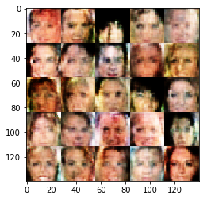

```
Epoch   1/1   Discriminator Loss: 1.16485 Generator Loss: 0.74646
Epoch   1/1   Discriminator Loss: 1.40480 Generator Loss: 0.53532
Epoch   1/1   Discriminator Loss: 1.03859 Generator Loss: 1.75222
Epoch   1/1   Discriminator Loss: 1.24519 Generator Loss: 0.94984
Epoch   1/1   Discriminator Loss: 1.55362 Generator Loss: 0.41598
Epoch   1/1   Discriminator Loss: 1.07137 Generator Loss: 1.29419
Epoch   1/1   Discriminator Loss: 1.42325 Generator Loss: 1.43204
Epoch   1/1   Discriminator Loss: 1.51841 Generator Loss: 0.42552
Epoch   1/1   Discriminator Loss: 1.22021 Generator Loss: 0.63284
Epoch   1/1   Discriminator Loss: 0.97508 Generator Loss: 1.06630
```

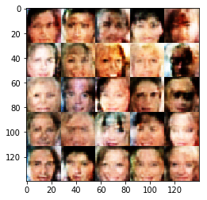

```
Epoch   1/1   Discriminator Loss: 1.39116 Generator Loss: 1.23727
Epoch   1/1   Discriminator Loss: 1.01648 Generator Loss: 0.95017
Epoch   1/1   Discriminator Loss: 1.07988 Generator Loss: 1.46309
Epoch   1/1   Discriminator Loss: 0.90132 Generator Loss: 1.20820
Epoch   1/1   Discriminator Loss: 0.94300 Generator Loss: 1.03735
Epoch   1/1   Discriminator Loss: 0.89270 Generator Loss: 1.25755
Epoch   1/1   Discriminator Loss: 1.31352 Generator Loss: 0.58026
Epoch   1/1   Discriminator Loss: 1.30279 Generator Loss: 0.64501
Epoch   1/1   Discriminator Loss: 1.05276 Generator Loss: 1.42282
Epoch   1/1   Discriminator Loss: 1.26383 Generator Loss: 1.30204
```

[9 more figures not shown]

```python
batch_size = 64
z_dim = 100
#learning_rate = 0.001
learning_rate = 0.0005
beta1 = 0.2

"""
DON'T MODIFY ANYTHING IN THIS CELL THAT IS BELOW THIS LINE
"""
epochs = 1

celeba_dataset = helper.Dataset('celeba', glob(os.path.join(data_dir, 'img_align_celeba/*.jpg')))
with tf.Graph().as_default():
    celeba_losses, celeba_samples = train(epochs, batch_size, z_dim, learning_rate, beta1,
                                          celeba_dataset.get_batches, celeba_dataset.shape,
                                          celeba_dataset.image_mode)
```

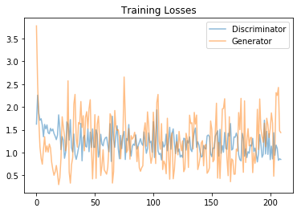

```python
plot_loss(celeba_losses)
```

```python
np.array(celeba_samples).shape
```

```
(21, 25, 28, 28, 3)
```

```
(<Figure size 504x504 with 25 Axes>,
 array([[<matplotlib.axes._subplots.AxesSubplot object at 0x7f000808f0b8>,
       dtype=object))
```

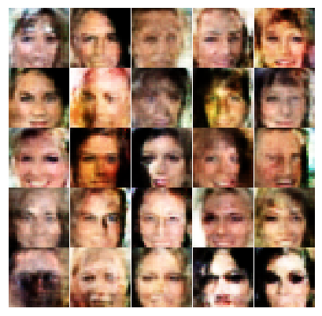

```python
view_samples(-1, celeba_samples, 5, 5, figsize=(7,7))
```

### Submitting This Project

When submitting this project, make sure to run all the cells before saving the notebook. Save the notebook file as "dlnd_face_generation.ipynb" and save it as a HTML file under "File" -> "Download as". Include the "helper.py" and "problem_unittests.py" files in your submission.